# Medidas de posição e dispersão

Mario Marcos de Faria

17/09/2026

# Sumário

1. Introdução
2. Objetivos
3. Descrição dos dados
4. Medidas de posição 4.1 Média aritmética 4.2 Mediana 4.3 Moda 4.4 Quartis 4.5 Percentis
5. Medidas de dispersão 5.1 Amplitude total 5.2 Amplitude interquartil 5.3 Variância 5.4 Desvio-padrão 5.5 Coeficiente de variação
6. Comparação entre grupos 6.1 Acesso à internet 6.2 Escolaridade da mãe 6.3 Faltas segundo o turno
7. Gráficos das distribuições 7.1 Boxplot das notas 7.2 Boxplot das faltas 7.3 Histograma das notas 7.4 Histograma das faltas
8. Correlação entre faltas e notas
9. Tabela estatística-síntese
10. Discussão
11. Respostas às questões de reflexão
12. Limitações
13. Conclusão
14. Referências
15. Resumo final dos resultados

# 1. Introdução

Este relatório apresenta uma análise estatística do banco de dados dos alunos, tendo como foco as **medidas de posição e dispersão**.

As principais variáveis quantitativas analisadas são o **número de faltas** e a **nota média** dos alunos.

O objetivo é utilizar medidas estatísticas, tabelas e gráficos para descrever o comportamento dos dados e comparar diferentes grupos de alunos.

A análise também procura discutir a importância de utilizar conjuntamente medidas de tendência central e medidas de dispersão, evitando conclusões baseadas exclusivamente na média.

# 2. Objetivos

Os objetivos deste relatório são:

1. calcular e interpretar medidas de posição;
2. calcular e interpretar medidas de dispersão;
3. analisar quartis e percentis;
4. comparar média e mediana;
5. construir tabelas estatísticas;
6. construir gráficos;
7. comparar diferentes grupos de alunos;
8. analisar a relação entre faltas e notas;
9. discutir as limitações de interpretações exclusivamente descritivas.

# 3. Descrição dos dados

O banco possui **1000 observações** e **5 variáveis**.

As variáveis quantitativas utilizadas na análise são:

- **faltas**;
- **nota média**.

Também são utilizadas, quando disponíveis no banco, as variáveis:

- **turno**;
- **escolaridade da mãe**;
- **acesso à internet**.

# 4. Medidas de posição

## 4.1 Média aritmética

A média aritmética das faltas foi:

**8.01 faltas.**

A média das notas foi:

**6.44 pontos.**

A média representa o valor obtido pela soma de todas as observações dividida pelo número de observações.

Média das variáveis quantitativas

| Variavel | Media |
| --- | --- |
| Faltas | 8.01 |
| Nota média | 6.44 |

## 4.2 Mediana

A mediana das faltas foi **8**.

A mediana das notas foi **6.5**.

A mediana é o valor que ocupa a posição central dos dados ordenados.

A comparação entre média e mediana mostra que as duas medidas são **próximas** para as faltas e **próximas** para as notas.

## 4.3 Moda

A moda das faltas foi:

**7**.

A moda das notas foi:

**10**.

A moda corresponde ao valor que apresenta maior frequência na distribuição.

## 4.4 Quartis

Os quartis obtidos foram:

Quartis das variáveis quantitativas

| Quartil | Faltas | Nota_media |
| --- | --- | --- |
| Q1 | 6 | 5.2 |
| Q2 - Mediana | 8 | 6.5 |
| Q3 | 10 | 7.7 |

O primeiro quartil, Q1, indica o valor abaixo do qual se encontram aproximadamente 25% das observações.

O segundo quartil, Q2, corresponde à mediana.

O terceiro quartil, Q3, indica o valor abaixo do qual se encontram aproximadamente 75% das observações.

## 4.5 Percentis

Os percentis calculados foram:

Percentis das variáveis quantitativas

| Percentil | Faltas | Nota_media |
| --- | --- | --- |
| P10 | 5 | 3.99 |
| P25 | 6 | 5.20 |
| P50 | 8 | 6.50 |
| P75 | 10 | 7.70 |
| P90 | 12 | 9.10 |
| P95 | 13 | 9.60 |

Os percentis permitem localizar uma observação dentro da distribuição.

Por exemplo, o P90 das notas foi **9.1**. Isso significa que aproximadamente 90% dos valores observados estão abaixo ou iguais a esse valor.

# 5. Medidas de dispersão

## 5.1 Amplitude total

A amplitude total é obtida pela diferença entre o maior e o menor valor:

$$A = valor\ máximo - valor\ mínimo$$

Amplitude total

| Variavel | Minimo | Maximo | Amplitude |
| --- | --- | --- | --- |
| Faltas | 1.0 | 19 | 18.0 |
| Nota média | 0.5 | 10 | 9.5 |

A amplitude das faltas foi **18**.

A amplitude das notas foi **9.5**.

## 5.2 Amplitude interquartil

A amplitude interquartil é calculada por:

$$AIQ = Q_3 - Q_1$$

Para as faltas:

**AIQ = 4**

Para as notas:

**AIQ = 2.5**

A amplitude interquartil descreve a dispersão dos 50% centrais dos dados.

## 5.3 Variância

A variância das faltas foi:

**7.83**

A variância das notas foi:

**3.54**

Variância das variáveis

| Variavel | Variancia |
| --- | --- |
| Faltas | 7.83 |
| Nota média | 3.54 |

A variância mede a dispersão dos valores em relação à média.

## 5.4 Desvio-padrão

O desvio-padrão das faltas foi:

**2.8**

O desvio-padrão das notas foi:

**1.88**

O desvio-padrão possui a mesma unidade da variável analisada e, por isso, possui interpretação mais direta do que a variância.

## 5.5 Coeficiente de variação

O coeficiente de variação é calculado por:

$$CV =
\frac{desvio\text{-}padrão}{média}
\times100$$

Os resultados foram:

- faltas: **34.93%**;
- nota média: **29.21%**.

A variável que apresentou maior variabilidade relativa foi **faltas**.

# 6. Comparação entre grupos

## 6.1 Questão — Acesso à internet

Quando a variável está disponível no banco, a comparação das notas segundo o acesso à internet é apresentada abaixo.

Notas segundo acesso à internet

| acesso_internet | N | Media | Mediana | Desvio_padrao | Minimo | Maximo |
| --- | --- | --- | --- | --- | --- | --- |
| Não | 297 | 6.48 | 6.5 | 1.90 | 1.1 | 10 |
| Sim | 703 | 6.43 | 6.5 | 1.87 | 0.5 | 10 |

O grupo que apresentou maior média de notas foi **Não**.

O grupo que apresentou menor média foi **Sim**.

A comparação deve considerar não apenas a média, mas também a mediana e o desvio-padrão.

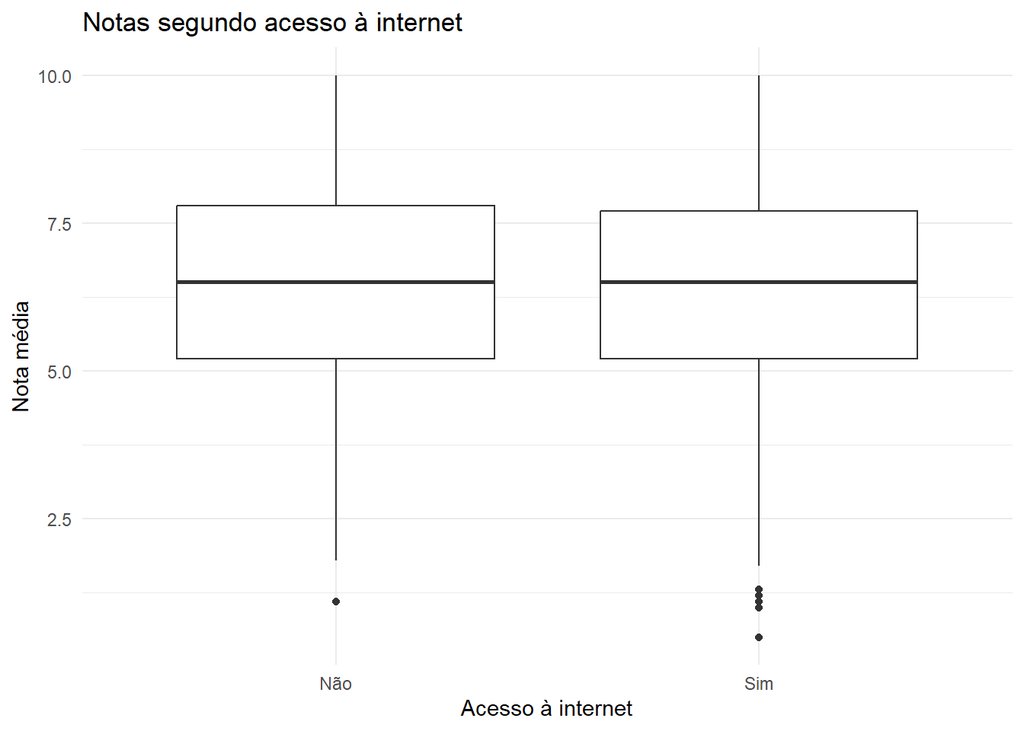

## 6.2 Questão — Escolaridade da mãe

Notas segundo escolaridade da mãe

| escolaridade_mae | N | Media | Mediana | Desvio_padrao | Minimo | Maximo | AIQ |
| --- | --- | --- | --- | --- | --- | --- | --- |
| Fundamental | 391 | 6.33 | 6.5 | 1.85 | 1.0 | 10 | 2.6 |
| Médio | 459 | 6.55 | 6.5 | 1.85 | 0.5 | 10 | 2.4 |
| Superior | 150 | 6.41 | 6.2 | 2.05 | 1.7 | 10 | 3.0 |

O grupo com maior média de notas foi **Médio**.

O grupo com menor média foi **Fundamental**.

Essas diferenças devem ser interpretadas com cautela, pois uma associação entre duas variáveis não significa necessariamente uma relação de causa e efeito.

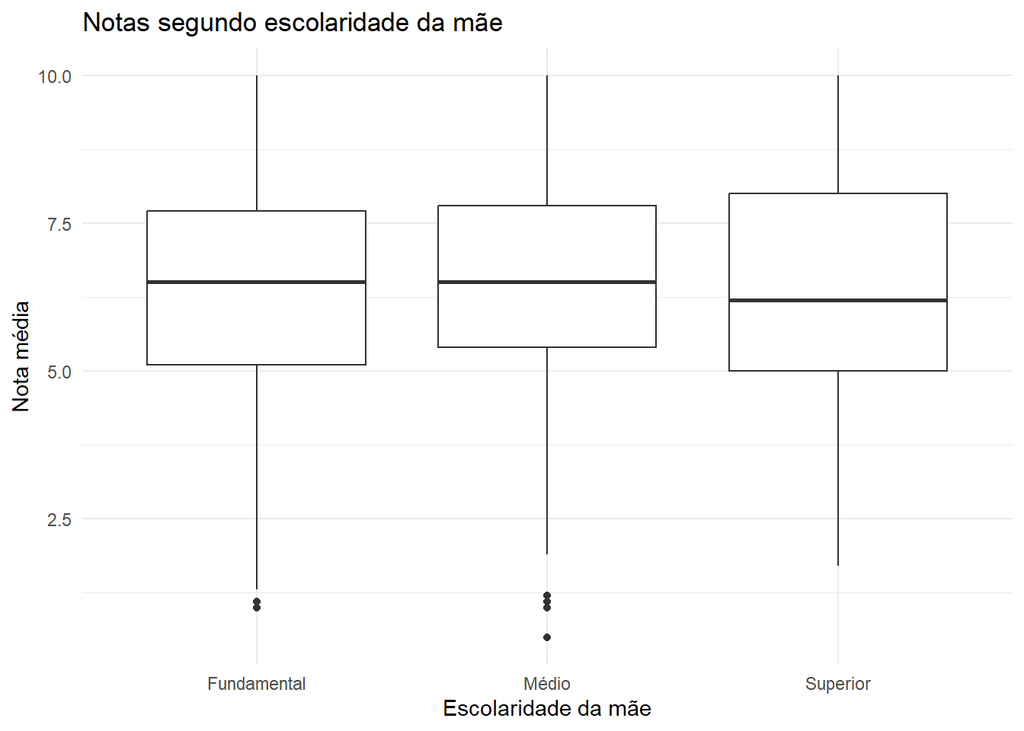

## 6.3 Questão — Faltas segundo o turno

Faltas segundo o turno

| turno | N | Media | Mediana | Desvio_padrao | Minimo | Maximo | AIQ |
| --- | --- | --- | --- | --- | --- | --- | --- |
| Matutino | 451 | 8.03 | 8 | 2.78 | 1 | 17 | 4 |
| Noturno | 204 | 7.95 | 8 | 2.65 | 2 | 15 | 3 |
| Vespertino | 345 | 8.03 | 8 | 2.91 | 1 | 19 | 4 |

O turno com maior média de faltas foi **Matutino**.

O turno com maior desvio-padrão foi **Vespertino**.

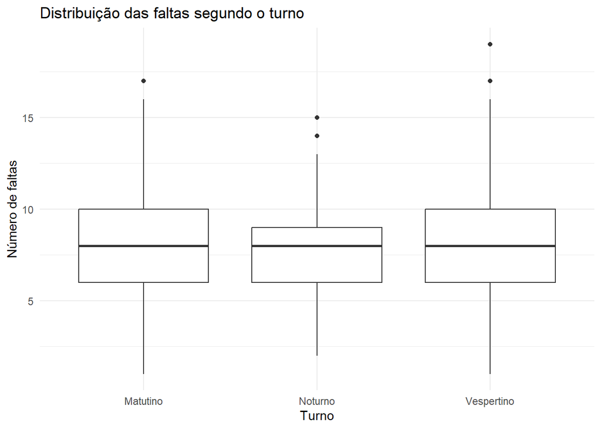

# 7. Gráficos das distribuições

## 7.1 Boxplot das notas

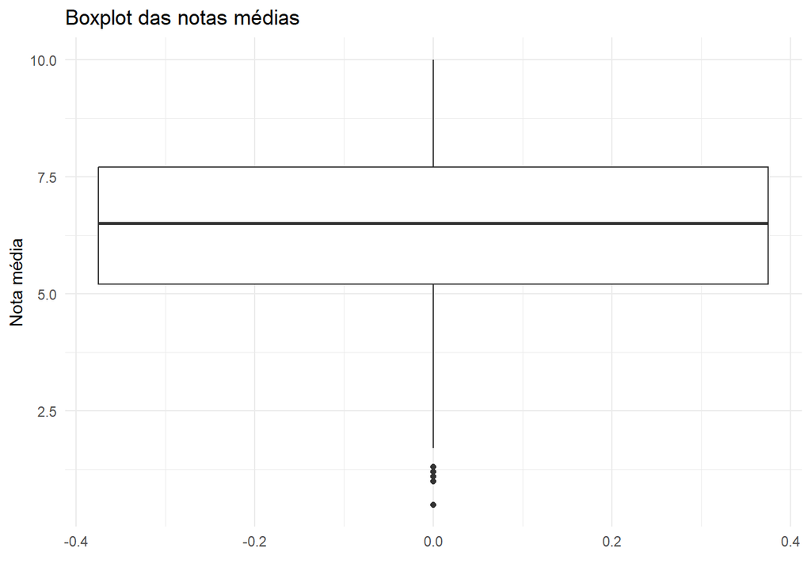

O boxplot permite visualizar a mediana, os quartis, a amplitude interquartil e possíveis valores discrepantes.

Foram identificados **7 possíveis valores discrepantes** pelo critério de 1,5 vezes a amplitude interquartil.

## 7.2 Boxplot das faltas

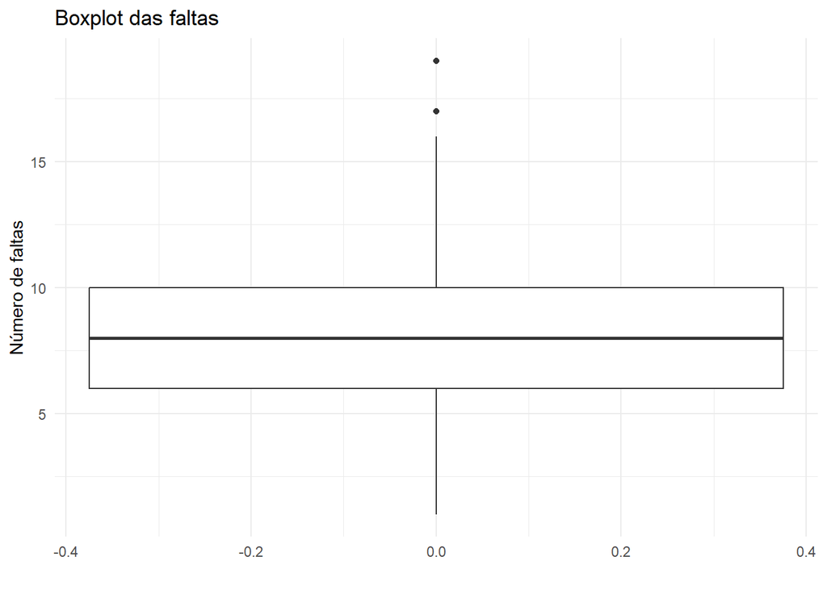

Foram identificados **3 possíveis valores discrepantes** pelo mesmo critério.

## 7.3 Histograma das notas

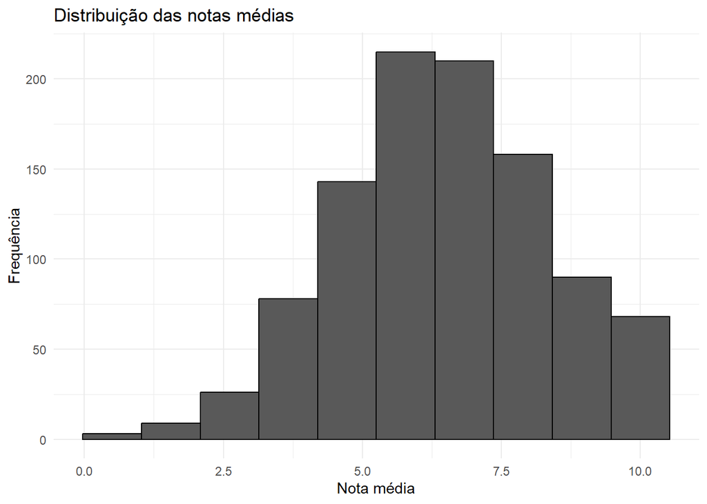

O histograma permite observar a concentração das notas ao longo da distribuição.

## 7.4 Histograma das faltas

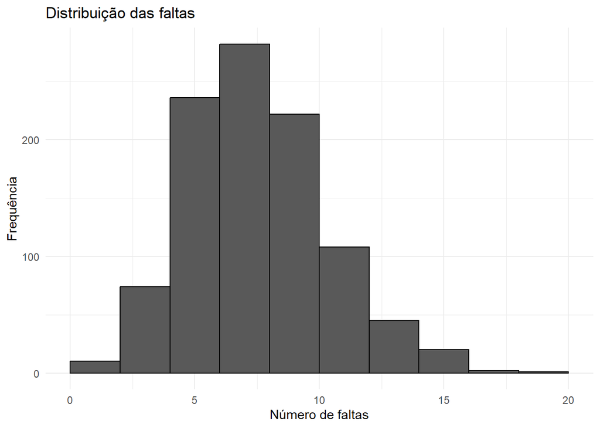

O histograma permite visualizar a frequência dos diferentes números de faltas.

# 8. Correlação entre faltas e notas

Foi calculado o coeficiente de correlação de Pearson entre o número de faltas e a nota média.

O resultado foi:

**r = -0.01**

O coeficiente de determinação foi:

**R² = 0**

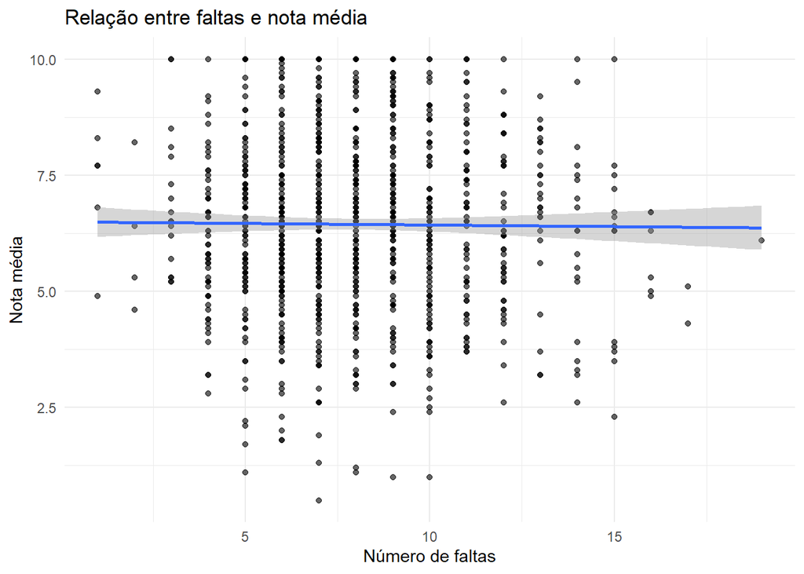

A correlação mede a associação linear entre as duas variáveis.

É importante destacar que correlação não implica necessariamente causalidade.

Portanto, mesmo que exista associação entre faltas e notas, não se pode concluir apenas com essa análise que uma variável seja responsável pela outra.

# 9. Tabela estatística-síntese

Síntese das medidas de posição e dispersão

| Medida | Faltas | Nota_media |
| --- | --- | --- |
| Média | 8.01 | 6.44 |
| Mediana | 8 | 6.5 |
| Moda | 7 | 10 |
| Mínimo | 1 | 0.5 |
| Máximo | 19 | 10 |
| Amplitude total | 18 | 9.5 |
| Q1 | 6 | 5.2 |
| Q2 | 8 | 6.5 |
| Q3 | 10 | 7.7 |
| Amplitude interquartil | 4 | 2.5 |
| Variância | 7.83 | 3.54 |
| Desvio-padrão | 2.8 | 1.88 |
| Coeficiente de variação (%) | 34.93 | 29.21 |

A tabela reúne as principais medidas calculadas para as duas variáveis quantitativas.

A observação conjunta dessas medidas fornece uma descrição mais completa do banco de dados.

# 10. Discussão

A análise demonstra que nenhuma medida estatística, isoladamente, é suficiente para descrever completamente uma distribuição.

A média permite identificar o centro aritmético dos dados.

A mediana permite identificar o valor central e possui menor sensibilidade aos valores extremos.

A moda permite identificar os valores mais frequentes.

Os quartis e percentis permitem analisar a posição relativa das observações.

Já a amplitude, a amplitude interquartil, a variância, o desvio-padrão e o coeficiente de variação permitem analisar a dispersão.

Essa combinação é especialmente importante na análise educacional, pois alunos que possuem médias semelhantes podem apresentar distribuições muito diferentes.

# 11. Respostas às questões de reflexão

## 11.1 Qual medida representa melhor o desempenho médio?

A média aritmética é apropriada para representar o desempenho médio quando se deseja considerar todas as observações.

Entretanto, caso existam valores extremos relevantes, a mediana pode representar melhor o desempenho típico.

No banco analisado, a média das notas foi **6.44**, enquanto a mediana foi **6.5**.

## 11.2 Qual medida representa melhor o número típico de faltas?

A mediana pode ser utilizada para representar o número típico de faltas, especialmente quando existem alunos com número de faltas muito elevado.

No conjunto analisado, a média foi **8.01** e a mediana foi **8**.

## 11.3 Qual variável apresenta maior variabilidade relativa?

De acordo com o coeficiente de variação, a variável **faltas** apresenta maior variabilidade relativa.

Essa comparação é mais apropriada do que comparar diretamente os desvios-padrão, pois as variáveis estão em escalas diferentes.

## 11.4 Por que analisar a dispersão?

A dispersão mostra quanto os alunos se afastam do comportamento central.

Duas turmas podem possuir a mesma média, mas uma delas pode apresentar notas muito concentradas enquanto a outra pode apresentar notas bastante espalhadas.

Por isso, a análise da dispersão complementa a análise da posição.

## 11.5 O que os gráficos acrescentam à análise?

Os gráficos permitem observar visualmente características que podem não ser evidentes apenas pelas tabelas.

Os histogramas mostram a forma da distribuição.

Os boxplots mostram mediana, quartis, dispersão e possíveis valores discrepantes.

Os gráficos por grupos permitem comparar visualmente diferentes categorias de alunos.

# 12. Limitações

Os resultados apresentados neste relatório são predominantemente descritivos.

Por esse motivo, as diferenças observadas entre grupos não devem ser interpretadas automaticamente como relações causais.

Por exemplo, uma diferença entre as notas de alunos com e sem acesso à internet não permite afirmar, isoladamente, que o acesso à internet seja a causa dessa diferença.

Outras variáveis podem estar relacionadas ao desempenho dos alunos.

Para estabelecer relações causais ou testar diferenças estatisticamente significativas seriam necessários procedimentos de estatística inferencial e um desenho de pesquisa adequado.

# 13. Conclusão

O estudo permitiu aplicar as principais medidas de posição e dispersão às variáveis faltas e nota média.

A média das faltas foi **8.01**, enquanto a média das notas foi **6.44**.

As medianas foram, respectivamente, **8** e **6.5**.

A análise dos quartis, percentis e medidas de dispersão complementou a interpretação dos dados.

O coeficiente de variação indicou que **faltas** apresentou maior variabilidade relativa.

Os gráficos possibilitaram visualizar a distribuição dos dados, enquanto as tabelas facilitaram a comparação dos resultados.

Conclui-se que uma análise estatística adequada deve combinar medidas de posição, medidas de dispersão e representações gráficas.

Além disso, diferenças encontradas entre grupos devem ser interpretadas com cautela, especialmente quando se pretende discutir possíveis relações de causa e efeito.

# 14. Referências

BRASIL. Instituto Brasileiro de Geografia e Estatística (IBGE). Estatística. Rio de Janeiro: IBGE.

R CORE TEAM. R: A language and environment for statistical computing. Vienna: R Foundation for Statistical Computing.

WICKHAM, H. ggplot2: Elegant Graphics for Data Analysis. 2. ed. Cham: Springer, 2016.

WICKHAM, H. et al. Welcome to the tidyverse. Journal of Open Source Software, v. 4, n. 43, 2019.

MONTGOMERY, D. C.; RUNGER, G. C. Estatística Aplicada e Probabilidade para Engenheiros. Rio de Janeiro: LTC.

Material de orientação fornecido para elaboração do relatório.

Banco de dados: dados_alunos.csv.

# 15. Resumo final dos resultados

```
## Número de alunos: 1000
##  Média de faltas: 8.01
##  Mediana de faltas: 8
##  Desvio-padrão das faltas: 2.8
##  CV das faltas: 34.93 %
##  Média das notas: 6.44
##  Mediana das notas: 6.5
##  Desvio-padrão das notas: 1.88
##  CV das notas: 29.21 %
##  Correlação faltas x notas: -0.01
```

[output not shown]